# In-Class Probability 3: Calculations in R

## Normal Probabilities

Q6 (1 pt.): Are you more likely to observe a value of 1.0 or 2.0?

A6. You’re more likely to observe a value of 1

Q7 (1 pt.): What is the probability of observing a value of 1.0 or less? Show the R code you used to find your answer.

```r
pbinom(q = 1, size = 8, prob = 0.24)
```

```
## [1] 0.3924912
```

Q8 (1 pt.): What is the probability of observing a value between 1.0 and 2.0? Show the R code you used to find your answer.

```r
a = pbinom(q = 1, size = 8, prob = 0.24)

b = pbinom(q = 2, size = 8, prob = 0.24)

c= b - a
```

## Normal Plots

Q9 (2 pts.): Show the complete R-code you used to create your plot. Make sure you include all the code to recreate your plot in a fresh R session.

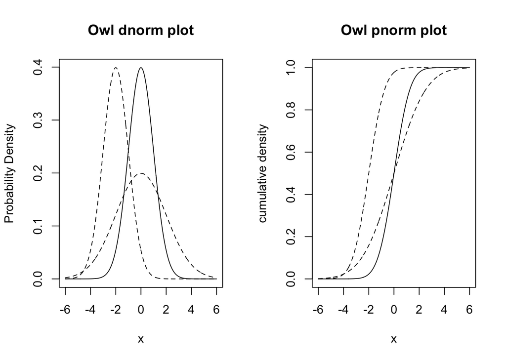

```r
par(mfrow = c(1, 2))

# How many points?
n = 1000

# Create a vector of x-values from -4 to 4:
x = seq(from = -6, to = 6, length.out = n)

# Create the corresponding y-values:
y = dnorm(x, mean = 0, sd = 1)
plot(y ~ x, type = "l", ylab = "Probability Density", main = "Owl dnorm plot")

y_2 = dnorm(x, mean = 0, sd = 2)
points(y_2 ~ x, type = "l", lty  = 2)

y_3 = dnorm(x, mean = -2, sd = 1)
points(y_3 ~ x, type = "l", lty  = 2)

y_cdf_1 = pnorm(x, mean = 0, sd = 1)
plot(y_cdf_1 ~ x, type = "l", ylab = "cumulative density", main = "Owl pnorm plot")

y_cdf_2 = pnorm(x, mean = 0, sd = 2)
points(y_cdf_2 ~ x, type = "l", lty = 2)

y_cdf_3 = pnorm(x, mean = -2 , sd = 1)
points(y_cdf_3 ~ x, type = "l", lty = 2)
```

Q10 (1 pt.): Include a figure of your plot.

## Binomial Plot

Q11 (2 pts.): Show the complete R-code you used to create your plot. Make sure you include all the code to recreate your plot in a fresh R session.

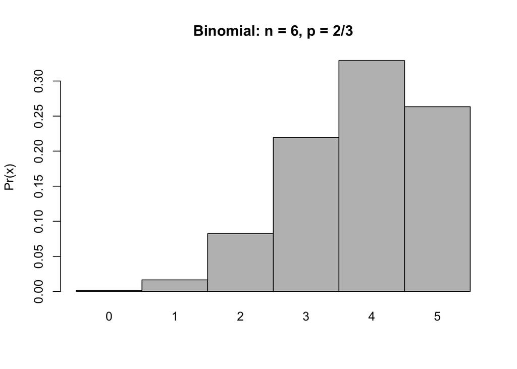

```r
x_bin = 0:5
y_bin_2 = dbinom(x_bin, size = 6, prob = 2/3)

barplot(
  height = y_bin_2,
  # the names to print with each bar:
  names.arg = x_bin,
  # Tells R to remove space between bars:
  space = 0,
  ylab = "Pr(x)",
  main = "Binomial: n = 6, p = 2/3")
```

Q12 (1 pt.): Include a figure of your plot.